# Ft Riley butterfly surveys

Preliminary assessment of IMAP data from 2021 - Monarch

Rexstad (CREEM Univ St Andrews)https://www.creem.st-andrews.ac.uk/  
2021-10-24

This exercises takes a first look at the 2021 Monarch butterfly survey. We take an initial look at the distribution of distances and fit models to the data. The models examine whether detection functions differ between the four sampling bouts of the season.

Load the necessary packages

```r
library(readxl)
library(Distance)
library(vioplot)
library(plotrix)
library(knitr)
library(kableExtra)
```

# Acquire data

```r
spreadsheet.monarch <- "IMAP Monarch Data_ALL.xlsx"
monarch <- as.data.frame(read_xlsx(path=spreadsheet.monarch, sheet="Sheet1"))
```

# Some renaming of fields

The `Distance` package is quite specific about the names associated with some elements of the data. For example, the field `observer` is specific to surveys that are conducted using multiple simultaneous observers to estimate detectability on the transect. As this is not the case for this survey, rename that field to `obsname` to avoid difficulties. I have also assigned the stratum identifier `Region.Label` to the sample bout, permitting easy estimation of bout-specific density.

```r
monarch$Area <- monarch$`Area (ha)`
monarch$Sample.Label <- monarch$`Transect ID`
monarch$Effort <- monarch$`Transect Length (m)`
monarch$distance <- monarch$`Distance (m)`
names(monarch)[9] <- "obsname"
monarch$sample.bout <- monarch$`Sample Bout`
monarch$Region.Label <- monarch$sample.bout
```

```r
bflyunits <- convert_units("meter", "meter", "hectare")
```

# Exploratory

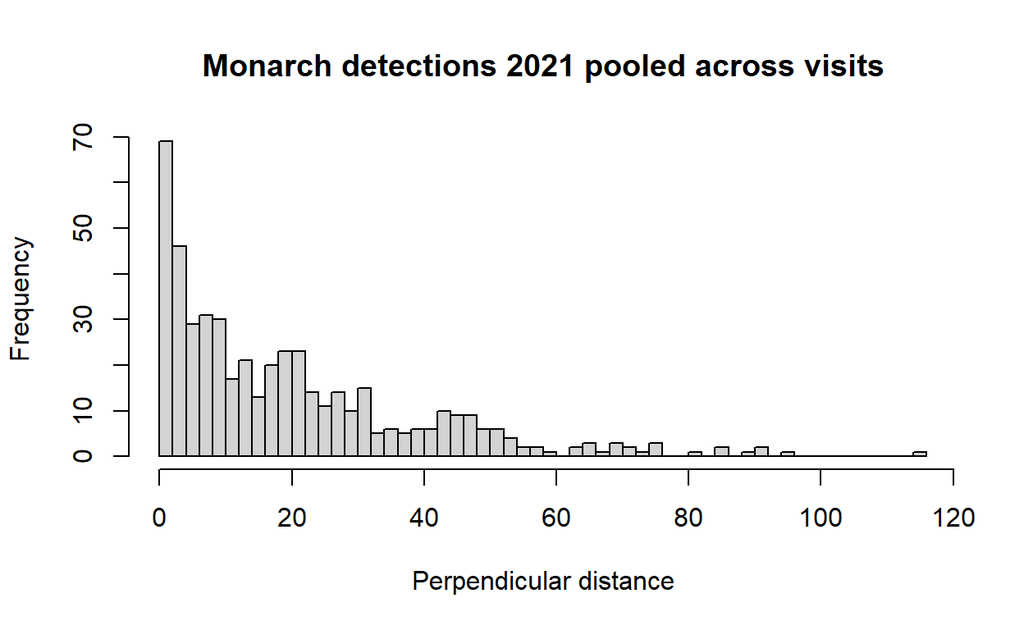

```r
hist(monarch$distance, nc=50, xlab="Perpendicular distance",
     main="Monarch detections 2021 pooled across visits")
```

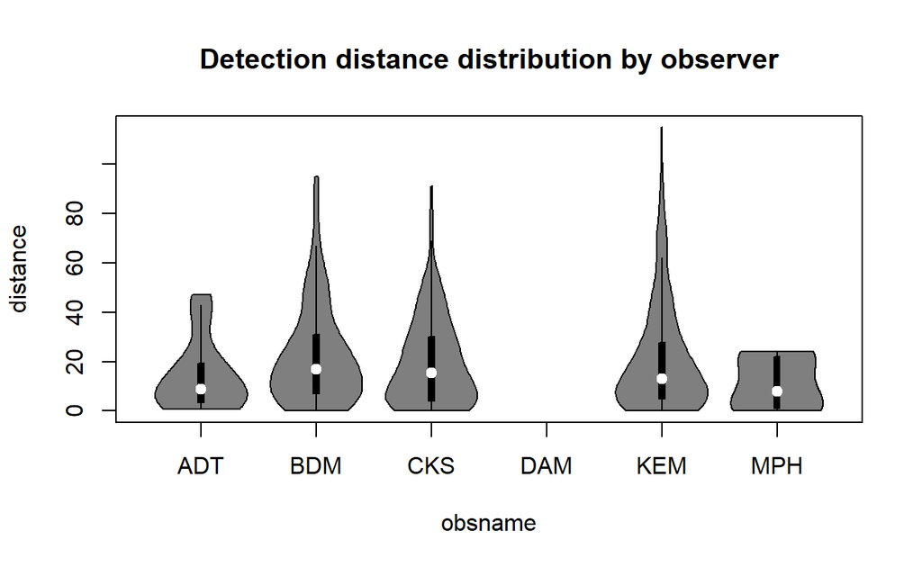

```r
obs <- unique(monarch$obsname)
vioplot(distance~obsname, data=monarch, main="Detection distance distribution by observer")
```

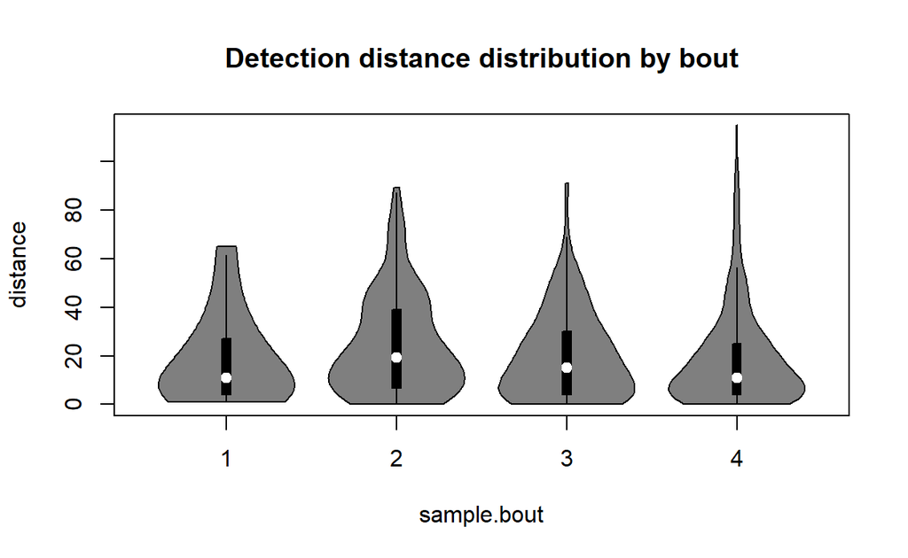

```r
vioplot(distance~sample.bout, data=monarch, main="Detection distance distribution by bout")
```

```r
b <- vector(mode="integer", length=4)
b[1] <- sum(!is.na(monarch$distance[monarch$sample.bout==1]))
b[2] <- sum(!is.na(monarch$distance[monarch$sample.bout==2]))
b[3] <- sum(!is.na(monarch$distance[monarch$sample.bout==3]))
b[4] <- sum(!is.na(monarch$distance[monarch$sample.bout==4]))
kable(data.frame(numdetect=b), row.names = TRUE, caption="Detections by sampling bout.")  %>%
  kable_paper(full_width=FALSE)
```

Table 1: Detections by sampling bout.

|  | numdetect |
| --- | --- |
| 1 | 29 |
| 2 | 113 |
| 3 | 110 |
| 4 | 234 |

Note I have chosen a truncation distance just short of 60m.

```r
w <- vector("numeric", 2)
p <- vector("numeric", 2)
mytrunc <- 58
monhn <- ds(data=monarch, key="hn", convert.units = bflyunits,
            formula=~as.factor(sample.bout), truncation = mytrunc)
hnfit <- gof_ds(monhn, plot=FALSE)$dsgof$CvM
w[1] <- round(hnfit$W, 4)
p[1] <- round(hnfit$p, 5)
monhr <- ds(data=monarch, key="hr", convert.units = bflyunits,
            formula=~as.factor(sample.bout), truncation = mytrunc)
hrfit <- gof_ds(monhr, plot=FALSE)$dsgof$CvM
w[2] <- round(hrfit$W, 4)
p[2] <- round(hrfit$p, 5)

kable(data.frame(w, p, row.names = c("Halfnorm", "Hazard")), row.names=TRUE,
      caption="Cramer-von Mises goodness of fit for two key function models.") %>%
    kable_paper(full_width=FALSE)
```

Table 2: Cramer-von Mises goodness of fit for two key function models.

|  | w | p |
| --- | --- | --- |
| Halfnorm | 1.8323 | 0.00003 |
| Hazard | 0.1095 | 0.54030 |

```r
summary(monhr$ddf)
```

```
Summary for ds object
Number of observations :  462
Distance range         :  0  -  58
AIC                    :  3507.949

Detection function:
 Hazard-rate key function

Detection function parameters
Scale coefficient(s):
                          estimate        se
(Intercept)              1.6676286 0.6994483
as.factor(sample.bout)2  0.9938038 0.7331349
as.factor(sample.bout)3  0.2161865 0.7092845
as.factor(sample.bout)4 -0.0836494 0.6844415

Shape coefficient(s):
             estimate        se
(Intercept) 0.0468316 0.1082622

                        Estimate           SE        CV
Average p              0.2830504   0.03329308 0.1176225
N in covered region 1632.2180829 202.77482433 0.1242327
```

```r
monhr.ests <- dht2(ddf=monhr, flatfile=monarch,
                  strat_formula = ~as.factor(sample.bout), convert_units = bflyunits,
                  stratification = "replicate")
print(monhr.ests, report="density")
```

```
Density estimates from distance sampling
Stratification : replicate
Variance       : R2, n/L
Multipliers    : none
Sample fraction : 1


Summary statistics:
 as.factor(sample.bout)  Area CoveredArea Effort   n   k    ER se.ER
                      1 40873       487.2  42000  27  84 0.001 0.000
                      2 40873       487.2  42000 105  84 0.002 0.001
                      3 40873       493.0  42500 108  85 0.003 0.000
                      4 40873       487.2  42000 222  84 0.005 0.001
                  Total 40873      1954.6 168500 462 337 0.003 0.000
 cv.ER
 0.259
 0.210
 0.186
 0.201
 0.117

Density estimates:
 as.factor(sample.bout) Estimate    se    cv    LCI    UCI      df
                      1   0.2198 0.116 0.527 0.0832 0.5809 509.503
                      2   0.4561 0.126 0.277 0.2671 0.7791 228.447
                      3   0.7502 0.201 0.269 0.4463 1.2611 298.218
                      4   1.9151 0.489 0.255 1.1666 3.1438 203.536
                  Total   0.8351 0.388 0.465 0.2245 3.1059   3.422

Component percentages of variance:
 as.factor(sample.bout) Detection    ER
                      1     17.10 82.90
                      2     23.91 76.09
                      3     28.46 71.54
                      4     25.57 74.43
                  Total     50.24 49.76
```

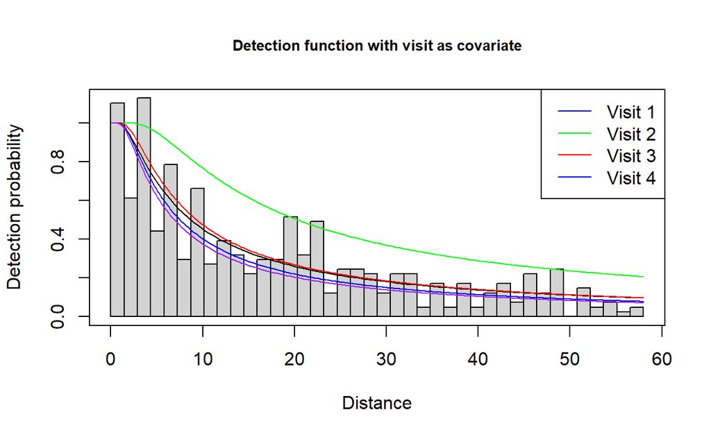

Figure 1: Hazard rate with bout-specific detection function.

```r
visitplot <- function(dsobject) {
# plots visit-specific detection functions
  plot(dsobject, showpoints=FALSE, nc=40,
       main="Detection function with visit as covariate")
  add_df_covar_line(dsobject, data=data.frame(sample.bout=as.factor(1)),
                    lty=1, col="blue")
  add_df_covar_line(dsobject, data=data.frame(sample.bout=as.factor(2)),
                    lty=1, col="green")
  add_df_covar_line(dsobject, data=data.frame(sample.bout=as.factor(3)),
                    lty=1, col="red")
  add_df_covar_line(dsobject, data=data.frame(sample.bout=as.factor(4)),
                    lty=1, col="purple")
  legend("topright", lty=1, legend=c("Visit 1", "Visit 2", "Visit 3", "Visit 4"),
         col=c("blue", "green", "red"))
}
visitplot(monhr)
```

# Pooled density analysis

```r
#monarch$Effort <- monarch$Effort * length(unique(monarch$sample.bout))
m.pool.hn <- ds(monarch, key="hn", convert.units = bflyunits, truncation = mytrunc)
m.pool.hr <- ds(monarch, key="hr", convert.units = bflyunits, truncation = mytrunc)
kable(summarize_ds_models(m.pool.hn, m.pool.hr)[,2:7], digits=4, row.names=FALSE)
```

| Key function | Formula | C-vM p-value | $\hat{P_a}$ | se($\hat{P_a}$) | $\Delta$AIC |
| --- | --- | --- | --- | --- | --- |
| Hazard-rate with cosine adjustment term of order 2 | ~1 | 0.7088 | 0.2646 | 0.0351 | 0.0000 |
| Half-normal with cosine adjustment term of order 2 | ~1 | 0.0366 | 0.4034 | 0.0199 | 13.2198 |

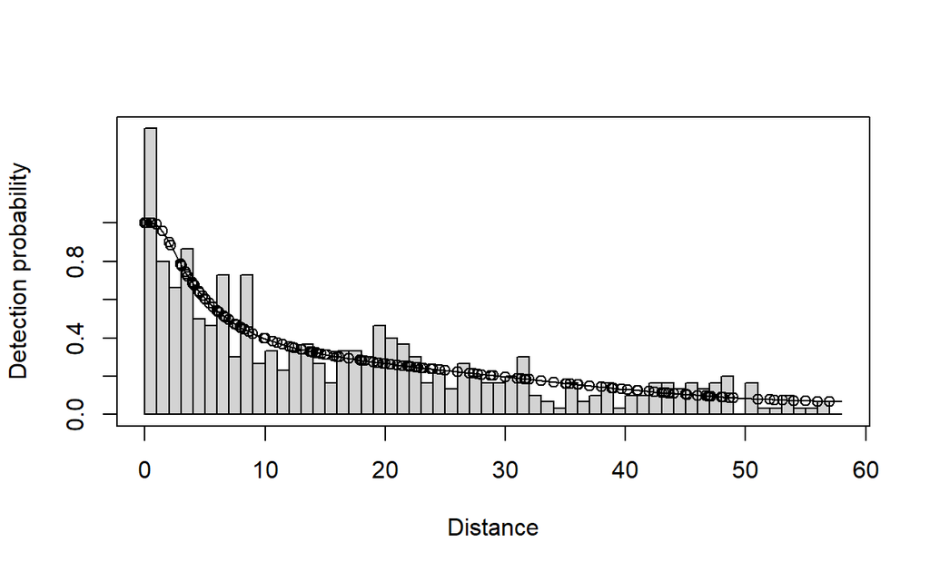

```r
plot(m.pool.hr, nc=58)
```

```r
summary(m.pool.hr)
```

```
Summary for distance analysis
Number of observations :  462
Distance range         :  0  -  58

Model : Hazard-rate key function with cosine adjustment term of order 2

Strict monotonicity constraints were enforced.
AIC   : 3508.077

Detection function parameters
Scale coefficient(s):
            estimate        se
(Intercept) 1.478918 0.2799944

Shape coefficient(s):
              estimate         se
(Intercept) 0.03901812 0.09718464

Adjustment term coefficient(s):
               estimate         se
cos, order 2 -0.2147768 0.09956485

                        Estimate           SE        CV
Average p              0.2646118   0.03510573 0.1326688
N in covered region 1745.9535846 241.88075834 0.1385379

Summary statistics:
  Region   Area CoveredArea Effort   n   k           ER        se.ER
1      1  40873         493  42500  27  85 0.0006352941 0.0001647059
2      2  40873         493  42500 105  85 0.0024705882 0.0005192616
3      3  40873         493  42500 108  85 0.0025411765 0.0004738403
4      4  40873         493  42500 222  85 0.0052235294 0.0010500602
5  Total 163492        1972 170000 462 340 0.0027176471 0.0003293826
      cv.ER
1 0.2592593
2 0.2101773
3 0.1864649
4 0.2010250
5 0.1212014

Abundance:
  Label   Estimate        se        cv        lcl       ucl       df
1     1   8459.488  2463.678 0.2912325   4810.928  14875.08 132.0947
2     2  32898.009  8176.694 0.2485468  20285.076  53353.46 159.6359
3     3  33837.952  7743.657 0.2288453  21667.257  52845.04 182.0348
4     4  69555.790 16752.995 0.2408569  43523.727 111157.94 167.2992
5 Total 144751.239 25626.777 0.1770401 102506.443 204405.89 540.6664

Density:
  Label  Estimate         se        cv       lcl       ucl       df
1     1 0.2069701 0.06027641 0.2912325 0.1177043 0.3639341 132.0947
2     2 0.8048836 0.20005123 0.2485468 0.4962953 1.3053473 159.6359
3     3 0.8278803 0.18945652 0.2288453 0.5301117 1.2929082 182.0348
4     4 1.7017540 0.40987927 0.2408569 1.0648528 2.7195934 167.2992
5 Total 0.8853720 0.15674637 0.1770401 0.6269814 1.2502501 540.6664
```

# Does detectability differ between sampling bouts?

AIC should provide an answer to this

```r
kable(summarize_ds_models(m.pool.hn, m.pool.hr, monhn, monhr)[,2:7], digits=4, row.names=FALSE)
```

| Key function | Formula | C-vM p-value | $\hat{P_a}$ | se($\hat{P_a}$) | $\Delta$AIC |
| --- | --- | --- | --- | --- | --- |
| Hazard-rate | ~as.factor(sample.bout) | 0.5403 | 0.2831 | 0.0333 | 0.0000 |
| Hazard-rate with cosine adjustment term of order 2 | ~1 | 0.7088 | 0.2646 | 0.0351 | 0.1279 |
| Half-normal with cosine adjustment term of order 2 | ~1 | 0.0366 | 0.4034 | 0.0199 | 13.3478 |
| Half-normal | ~as.factor(sample.bout) | 0.0000 | 0.5049 | 0.0166 | 33.7087 |

# Bout-specific estimates under hazard rate models

There appears to be little difference between the pooled and bout-specific detection function models. Examine the point and interval estimates under each model:

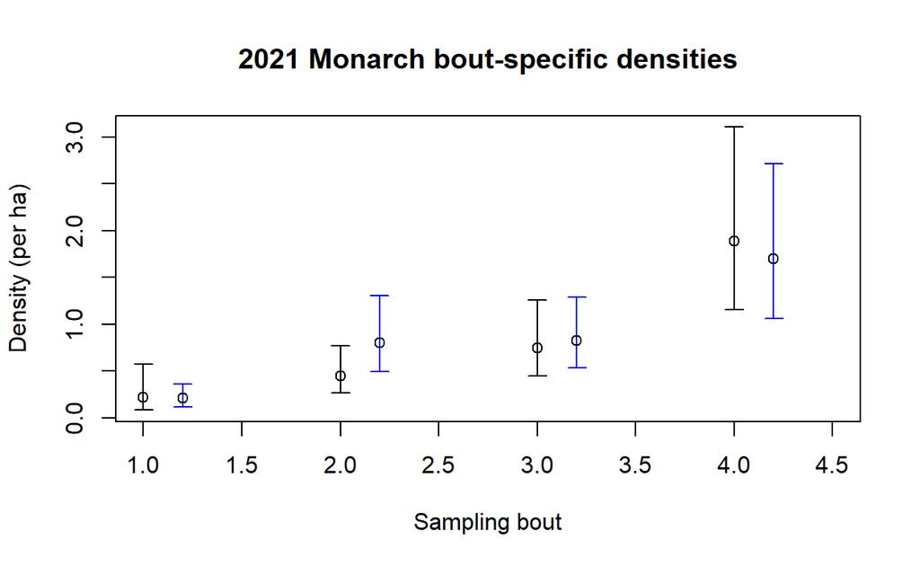

```r
plotCI(1:4, monhr$dht$individuals$D$Estimate[1:4], li=monhr$dht$individuals$D$lcl[1:4],
       ui=monhr$dht$individuals$D$ucl[1:4], main="2021 Monarch bout-specific densities",
       xlab="Sampling bout", ylab="Density (per ha)", xlim=c(1, 4.5))
plotCI(1:4+.2, m.pool.hr$dht$individuals$D$Estimate[1:4], li=m.pool.hr$dht$individuals$D$lcl[1:4],
       ui=m.pool.hr$dht$individuals$D$ucl[1:4], add=TRUE, scol="blue", pt.bg = "blue")
```

# Comments

## Spike on the transect

Note the large proportion of detections in the first meter 9.74% of all detections are in the first meter (the first 1.7% of the sampled strip). This leads to a spike close to zero, which is difficult to fit. There are three consequences:

- there is great discrepancy in $\widehat{P_a}$ between the half normal key function and the hazard rate key function
- the chosen (hazard rate model) predicts detectability falls off precipitously
  - probability of detecting a butterfly at 7m is roughly 0.5 (for every butterfly detected at 7m, there is another undetected)
    - in contrast, the half-normal key function predicts the 0.5 detection probability threshold is crossed at ~18m. Field experience plays a role in assessing which model is most plausible.
  - this results in $\widehat{P_a}$ being relatively small (0.265) and a subsequent large estimate of density ($\hat{D}=$ 0.885 $\cdot ha^{-1}$)
- contrary to the usual situation with line transect data where 25% of the uncertainty in the density estimate is attributable to uncertainty in the detection function, here 56.2% of the uncertainty comes from the detection function.

## Comparison of overall estimates

Bout-specific estimates of density are highly variably, building to a crescendo in the September sample. Except for the first bout, when <30 detections were made, the CV($\hat{D}$) remain reasonably constant.

- Combining those bout-specific density estimates into an overall estimate (that takes into account temporal variability) has a large CV($\hat{D}$) (0.465).
- The point estimate of $\hat{D}$ for the analysis of the pooled data is similar, but more precise (CV=0.177), because temporal variability is not incorporated.